# Final Project

## Set-Up

I read in the data set given from Kaggle and then cut its size down.

```r
library(readr)
library(knitr)
library(png)
library(dplyr)
```

```r
library(ggplot2)
library(viridis)
library(stringi)
library(tokenizers)
library(smodels)

allstate <- read_csv("C:/Users/Gregory/Desktop/train.csv")
allstate <- filter(allstate, allstate$customer_ID < 10006417)
```

```r
allstate
```

```
## # A tibble: 27,364 x 25
##    customer_ID shopping_pt record_type   day     time state location
##          <int>       <int>       <int> <int>   <time> <chr>    <int>
##  1    10000000           1           0     0 08:35:00    IN    10001
##  2    10000000           2           0     0 08:38:00    IN    10001
##  3    10000000           3           0     0 08:38:00    IN    10001
##  4    10000000           4           0     0 08:39:00    IN    10001
##  5    10000000           5           0     0 11:55:00    IN    10001
##  6    10000000           6           0     0 11:57:00    IN    10001
##  7    10000000           7           0     0 11:58:00    IN    10001
##  8    10000000           8           0     0 12:03:00    IN    10001
##  9    10000000           9           1     0 12:07:00    IN    10001
## 10    10000005           1           0     3 08:56:00    NY    10006
## # ... with 27,354 more rows, and 18 more variables: group_size <int>,
## #   homeowner <int>, car_age <int>, car_value <chr>, risk_factor <int>,
## #   age_oldest <int>, age_youngest <int>, married_couple <int>,
## #   C_previous <int>, duration_previous <int>, A <int>, B <int>, C <int>,
## #   D <int>, E <int>, F <int>, G <int>, cost <int>
```

## Variable Description

customer_ID - A unique identifier for the customer

shopping_pt - Unique identifier for the shopping point of a given customer

record_type - 0=shopping point, 1=purchase point

day - Day of the week (0-6, 0=Monday)

time - Time of day (HH:MM)

state - State where shopping point occurred

location - Location ID where shopping point occurred

group_size - How many people will be covered under the policy (1, 2, 3 or 4)

homeowner - Whether the customer owns a home or not (0=no, 1=yes)

car_age - Age of the customer’s car

car_value - How valuable was the customer’s car when new

risk_factor - An ordinal assessment of how risky the customer is (1, 2, 3, 4)

age_oldest - Age of the oldest person in customer’s group

age_youngest - Age of the youngest person in customer’s group

married_couple - Does the customer group contain a married couple (0=no, 1=yes)

C_previous - What the customer formerly had or currently has for product option C (0=nothing, 1, 2, 3,4)

duration_previous - how long (in years) the customer was covered by their previous issuer

A,B,C,D,E,F,G - the coverage options

cost - cost of the quoted coverage options

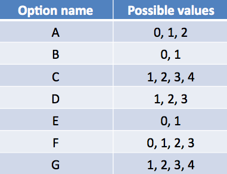

```r
img1_path <- "C:/Users/Gregory/Desktop/product_options.png"
img1 <- readPNG(img1_path, native = TRUE, info = TRUE)
include_graphics(img1_path)
```

## Train, Valid, Test

Created the train, test, and valid sets. I broke them up by customer ID because there is not pattern in customer ID and cost so this is essentially the same thing as breaking them up randomly. I then took all of the column with record type 1 from the valid set and made it the test set because I am trying to predict the the cost of what customers will buy based on previous customers and the quotes that the customers have already been given.

```r
allstate$train_id <- 1
allstate$train_id[allstate$customer_ID < 10004681]="Train"
allstate$train_id[allstate$customer_ID >= 10004681]="Valid"
allstate$train_id[allstate$train_id == "Valid" & allstate$record_type == 1]="Test"
```

## Single Variable for Type of Plan

I made a single variable for the type of plan as given by the variables A-G. I did this by combining the numbers given from A-G and making a sort of id code for each plan. Then I used a code the give a number starting with for each unique value of the plan code I made. I subtracted 1 from that so the plans start with 0.

```r
allstate$plan <- as.numeric(paste(allstate$A, allstate$B, allstate$C, allstate$D, allstate$E, allstate$F, allstate$G, sep = ""))

allstate$plan <- sprintf("%07d",allstate$plan)

allstate <- transform(allstate,id=as.numeric(factor(allstate$plan)))

allstate$id <- allstate$id - 1
```

## New Variables

I created a continuous variable for time. Since there were no values for some of the variables I replaced them with 0.

```r
allstate$time <- as.numeric(as.POSIXct(allstate$time))

allstate$risk_factor[is.na(allstate$risk_factor)] <- 0
allstate$C_previous[is.na(allstate$C_previous)] <- 0
allstate$duration_previous[is.na(allstate$duration_previous)] <- 0
```

## Answers for the Test Set

I created a data frame with the answers to the customers I am predicting for future reference.

```r
Test_Answers <- filter(allstate, allstate$train_id == "Test")
Test_Answers <- select(Test_Answers, customer_ID, train_id, cost)
train_valid <- filter(allstate, train_id == "Train" | train_id == "Valid")
```

## Removing Values for Customers I am Predicting

Since I am predicting the cost for the test set I obviously should not know the cost of the plan for these customers. But since they also have not bought the plan yet I also do not know the id or plan as well as the values of A-G.

```r
allstate$cost[allstate$train_id == "Test"]=NA

allstate$id[allstate$train_id == "Test"]=NA
allstate$plan[allstate$train_id == "Test"]=NA

allstate$A[allstate$train_id == "Test"]=NA
allstate$B[allstate$train_id == "Test"]=NA
allstate$C[allstate$train_id == "Test"]=NA
allstate$D[allstate$train_id == "Test"]=NA
allstate$E[allstate$train_id == "Test"]=NA
allstate$F[allstate$train_id == "Test"]=NA
allstate$G[allstate$train_id == "Test"]=NA

allstate$time[allstate$train_id == "Test"]=NA
allstate$day[allstate$train_id == "Test"]=NA
```

## Summary

I made a table of the minimum, 1st quartile, median, mean, 3rd quartile, and maximum for all of the variables.

```r
summary(allstate)
```

```
##   customer_ID        shopping_pt      record_type          day
##  Min.   :10000000   Min.   : 1.000   Min.   :0.0000   Min.   :0.000
##  1st Qu.:10001588   1st Qu.: 2.000   1st Qu.:0.0000   1st Qu.:1.000
##  Median :10003170   Median : 4.000   Median :0.0000   Median :2.000
##  Mean   :10003187   Mean   : 4.214   Mean   :0.1458   Mean   :1.969
##  3rd Qu.:10004818   3rd Qu.: 6.000   3rd Qu.:0.0000   3rd Qu.:3.000
##  Max.   :10006412   Max.   :13.000   Max.   :1.0000   Max.   :6.000
##                                                       NA's   :1074
##       time          state              location       group_size
##  Min.   :22080   Length:27364       Min.   :10001   Min.   :1.000
##  1st Qu.:39420   Class :character   1st Qu.:10594   1st Qu.:1.000
##  Median :47400   Mode  :character   Median :11329   Median :1.000
##  Mean   :47272                      Mean   :11435   Mean   :1.229
##  3rd Qu.:54780                      3rd Qu.:12198   3rd Qu.:1.000
##  Max.   :82320                      Max.   :13422   Max.   :4.000
##  NA's   :1074
##    homeowner         car_age        car_value          risk_factor
##  Min.   :0.0000   Min.   : 0.000   Length:27364       Min.   :0.000
##  1st Qu.:0.0000   1st Qu.: 4.000   Class :character   1st Qu.:0.000
##  Median :1.0000   Median : 7.000   Mode  :character   Median :1.000
##  Mean   :0.5346   Mean   : 8.167                      Mean   :1.618
##  3rd Qu.:1.0000   3rd Qu.:11.000                      3rd Qu.:3.000
##  Max.   :1.0000   Max.   :59.000                      Max.   :4.000
##
##    age_oldest     age_youngest   married_couple    C_previous
##  Min.   :18.00   Min.   :16.00   Min.   :0.000   Min.   :0.000
##  1st Qu.:28.00   1st Qu.:26.00   1st Qu.:0.000   1st Qu.:1.000
##  Median :43.00   Median :39.00   Median :0.000   Median :3.000
##  Mean   :44.52   Mean   :42.23   Mean   :0.209   Mean   :2.389
##  3rd Qu.:59.00   3rd Qu.:56.00   3rd Qu.:0.000   3rd Qu.:3.000
##  Max.   :75.00   Max.   :75.00   Max.   :1.000   Max.   :4.000
##
##  duration_previous       A                B                C
##  Min.   : 0.000    Min.   :0.0000   Min.   :0.0000   Min.   :1.000
##  1st Qu.: 2.000    1st Qu.:1.0000   1st Qu.:0.0000   1st Qu.:1.000
##  Median : 4.000    Median :1.0000   Median :0.0000   Median :2.000
##  Mean   : 5.701    Mean   :0.9286   Mean   :0.4624   Mean   :2.284
##  3rd Qu.: 9.000    3rd Qu.:1.0000   3rd Qu.:1.0000   3rd Qu.:3.000
##  Max.   :15.000    Max.   :2.0000   Max.   :1.0000   Max.   :4.000
##                    NA's   :1074     NA's   :1074     NA's   :1074
##        D               E                F               G
##  Min.   :1.000   Min.   :0.0000   Min.   :0.000   Min.   :1.000
##  1st Qu.:2.000   1st Qu.:0.0000   1st Qu.:0.000   1st Qu.:2.000
##  Median :3.000   Median :0.0000   Median :1.000   Median :2.000
##  Mean   :2.453   Mean   :0.4412   Mean   :1.165   Mean   :2.276
##  3rd Qu.:3.000   3rd Qu.:1.0000   3rd Qu.:2.000   3rd Qu.:3.000
##  Max.   :3.000   Max.   :1.0000   Max.   :3.000   Max.   :4.000
##  NA's   :1074    NA's   :1074     NA's   :1074    NA's   :1074
##       cost         train_id             plan                 id
##  Min.   :456.0   Length:27364       Length:27364       Min.   :  0.0
##  1st Qu.:605.0   Class :character   Class :character   1st Qu.:226.0
##  Median :634.5   Mode  :character   Mode  :character   Median :392.0
##  Mean   :636.1                                         Mean   :401.7
##  3rd Qu.:665.0                                         3rd Qu.:566.0
##  Max.   :860.0                                         Max.   :989.0
##  NA's   :1074                                          NA's   :1074
```

## Plots

### Shopping Point vs. Cost

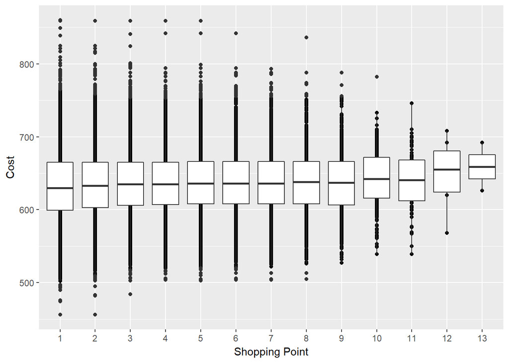

```r
qplot(factor(allstate$shopping_pt), allstate$cost, data =  allstate) + geom_boxplot() + xlab("Shopping Point") + ylab("Cost")
```

### Record Type vs. Cost

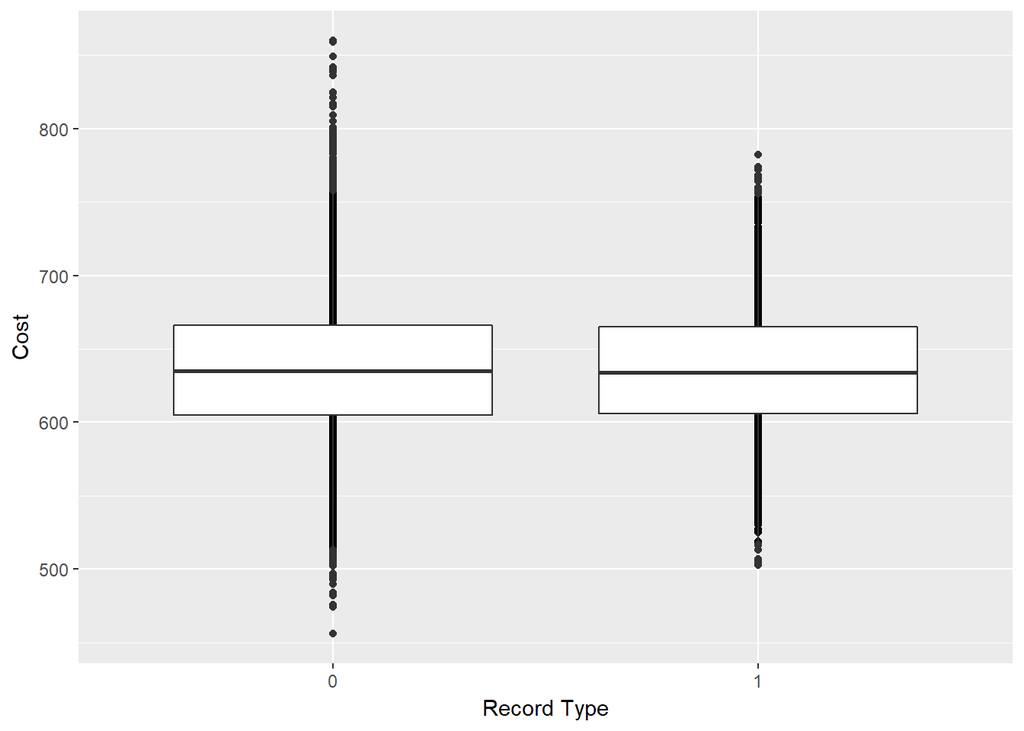

```r
qplot(factor(allstate$record_type), allstate$cost, data =  allstate) + geom_boxplot() + xlab("Record Type") + ylab("Cost")
```

### Day of the Week vs. Cost

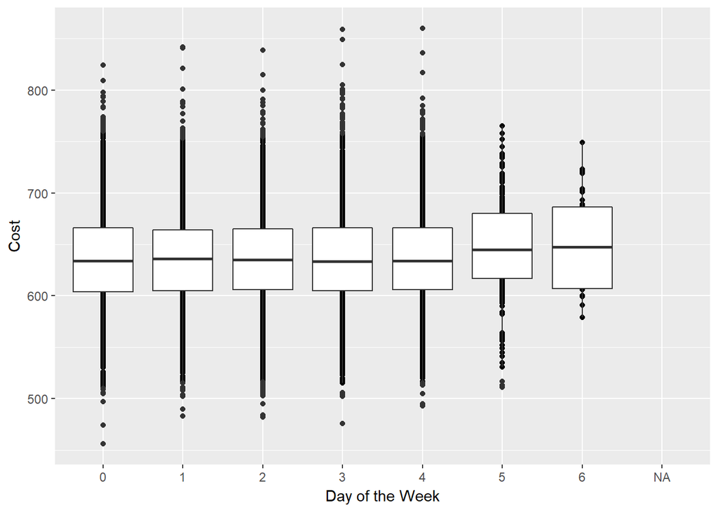

```r
qplot(factor(allstate$day), allstate$cost, data =  allstate) + geom_boxplot() + xlab("Day of the Week") + ylab("Cost")
```

### Time vs. Cost

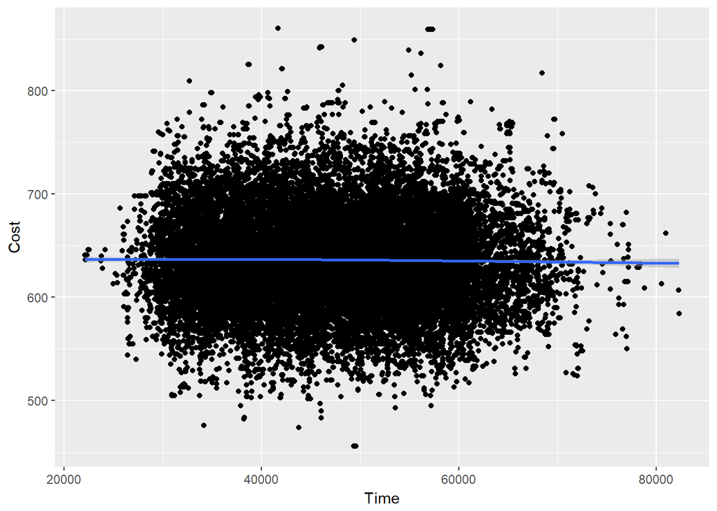

```r
qplot(allstate$time, allstate$cost, data = allstate) + geom_smooth() + xlab("Time") + ylab("Cost")
```

### Plan vs. Cost

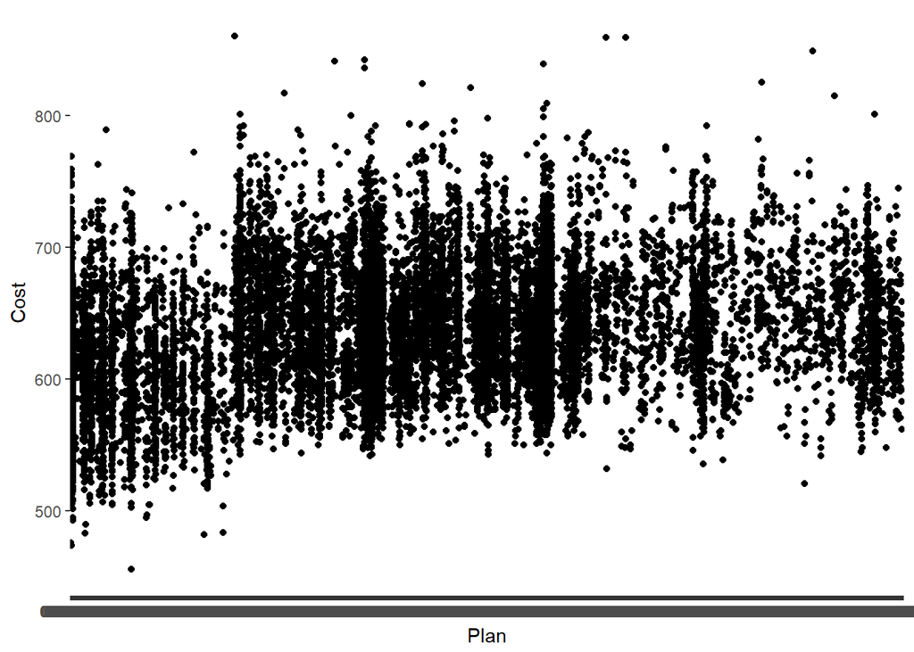

```r
qplot(factor(allstate$plan), allstate$cost, allstate) + xlab("Plan") + ylab("Cost")
```

### State vs. Cost

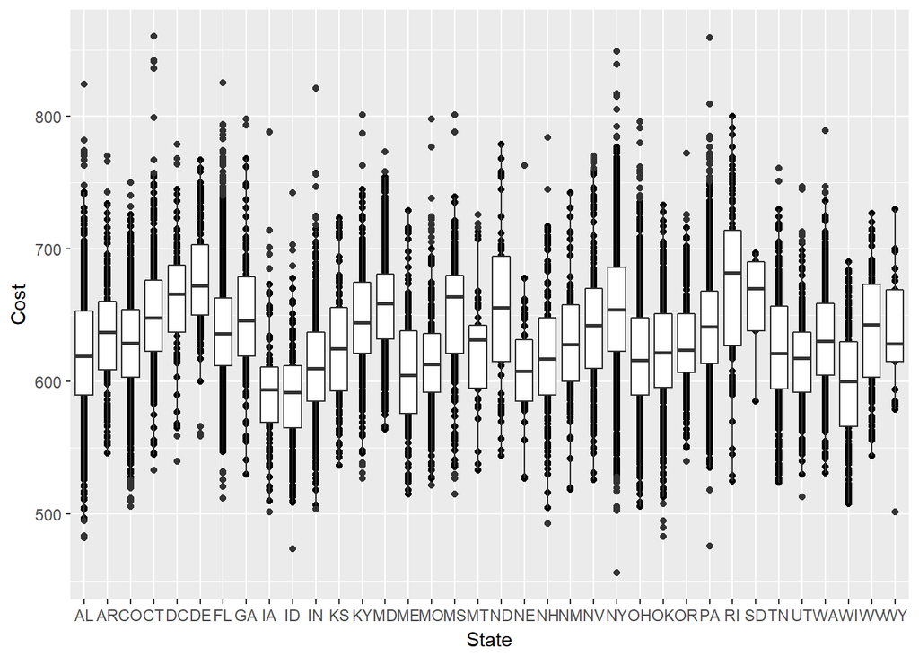

```r
qplot(factor(allstate$state), allstate$cost, data = allstate) + geom_boxplot() + xlab("State") + ylab("Cost")
```

### Risk Factor vs. Cost

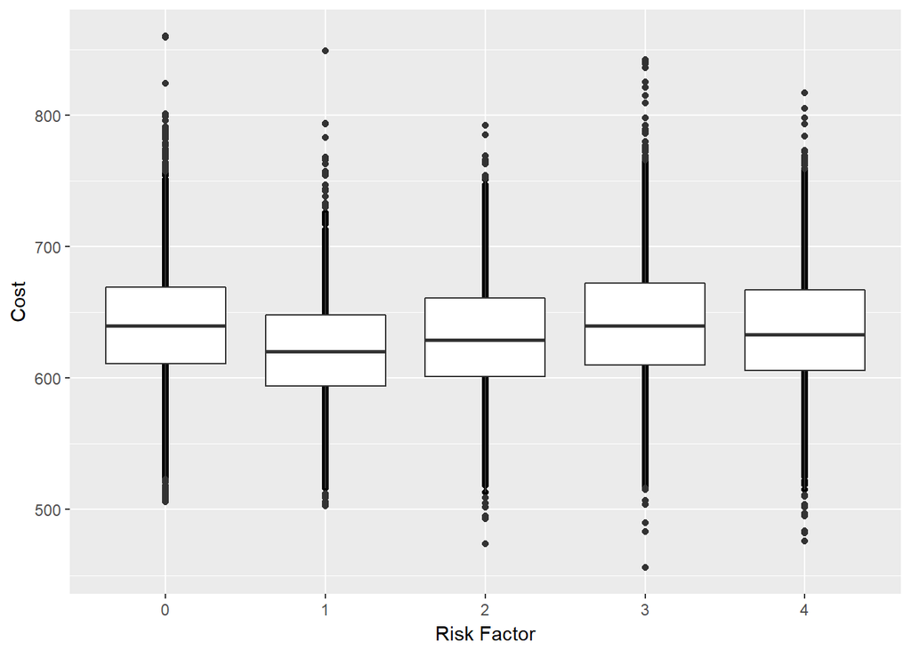

```r
qplot(factor(allstate$risk_factor), allstate$cost, data = allstate) + geom_boxplot() + xlab("Risk Factor") + ylab("Cost")
```

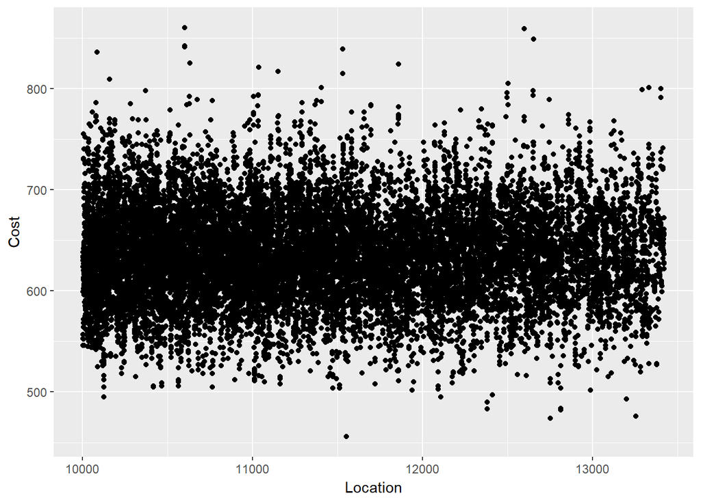

```r
qplot(allstate$location, allstate$cost, data = allstate)+ xlab("Location") + ylab("Cost")
```

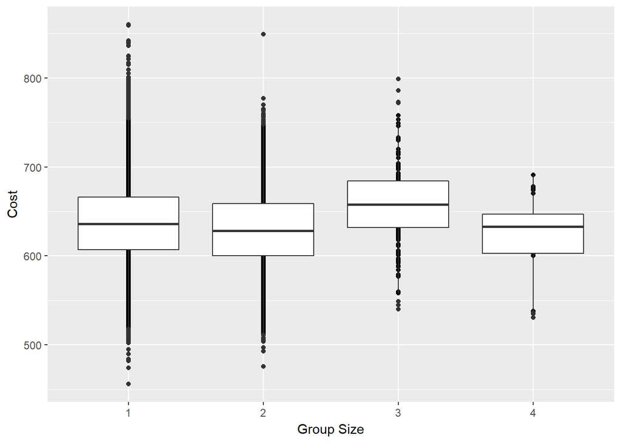

```r
qplot(factor(allstate$group_size), allstate$cost, data = allstate) + geom_boxplot() + xlab("Group Size") + ylab("Cost")
```

### Homeowner vs. Cost

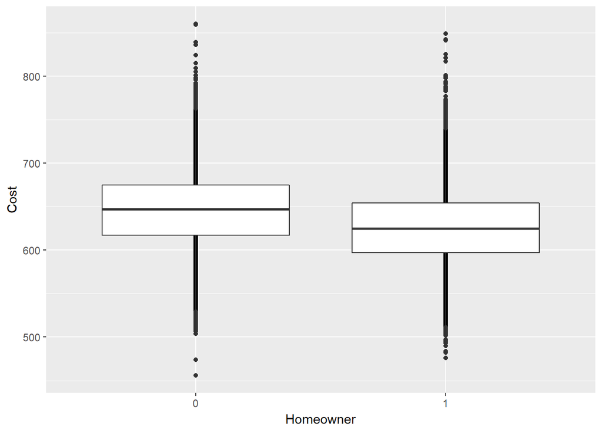

```r
qplot(factor(allstate$homeowner), allstate$cost, data = allstate) + geom_boxplot() + xlab("Homeowner") + ylab("Cost")
```

### Car Age vs. Cost

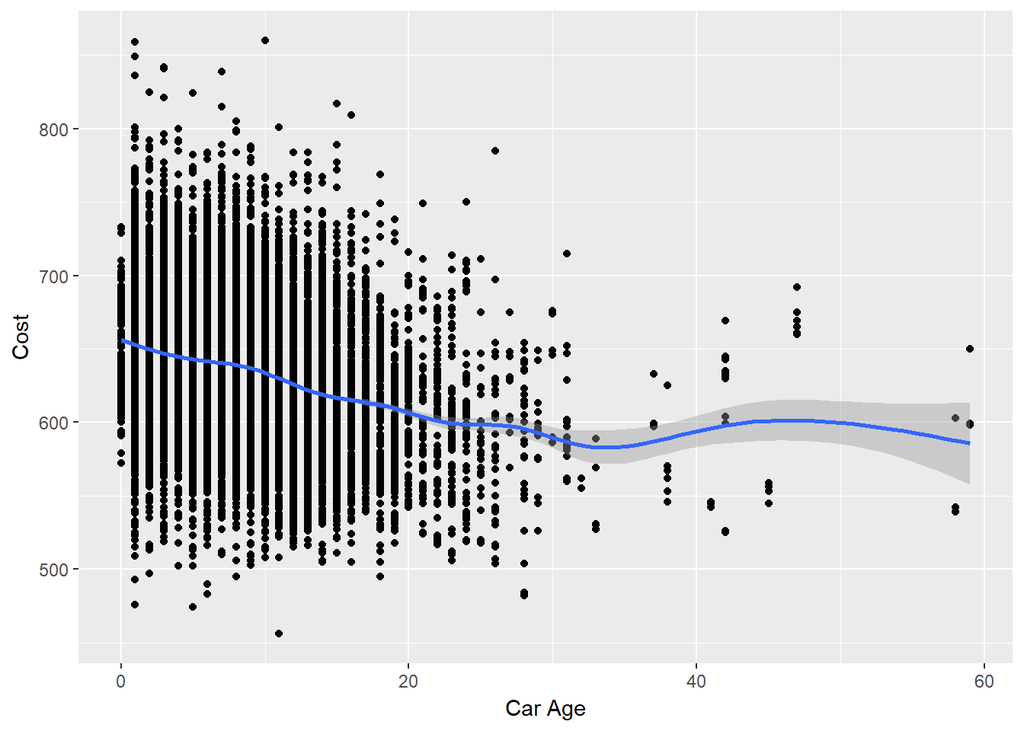

```r
qplot(allstate$car_age, allstate$cost, data = allstate) + geom_smooth() + xlab("Car Age") + ylab("Cost")
```

### Car Value vs. Cost

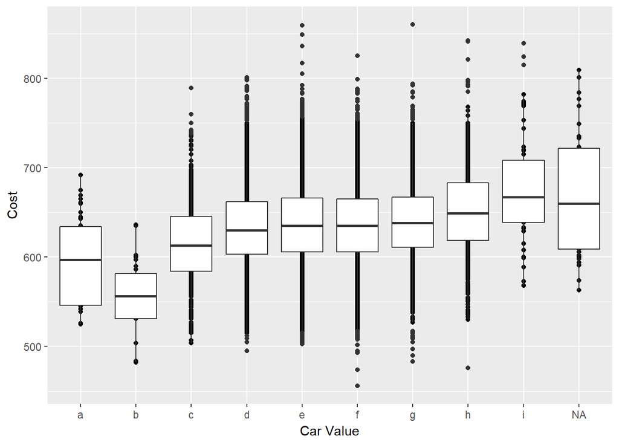

```r
qplot(factor(allstate$car_value), allstate$cost, data = allstate) + geom_boxplot() + xlab("Car Value") + ylab("Cost")
```

### Age Oldest vs. Cost

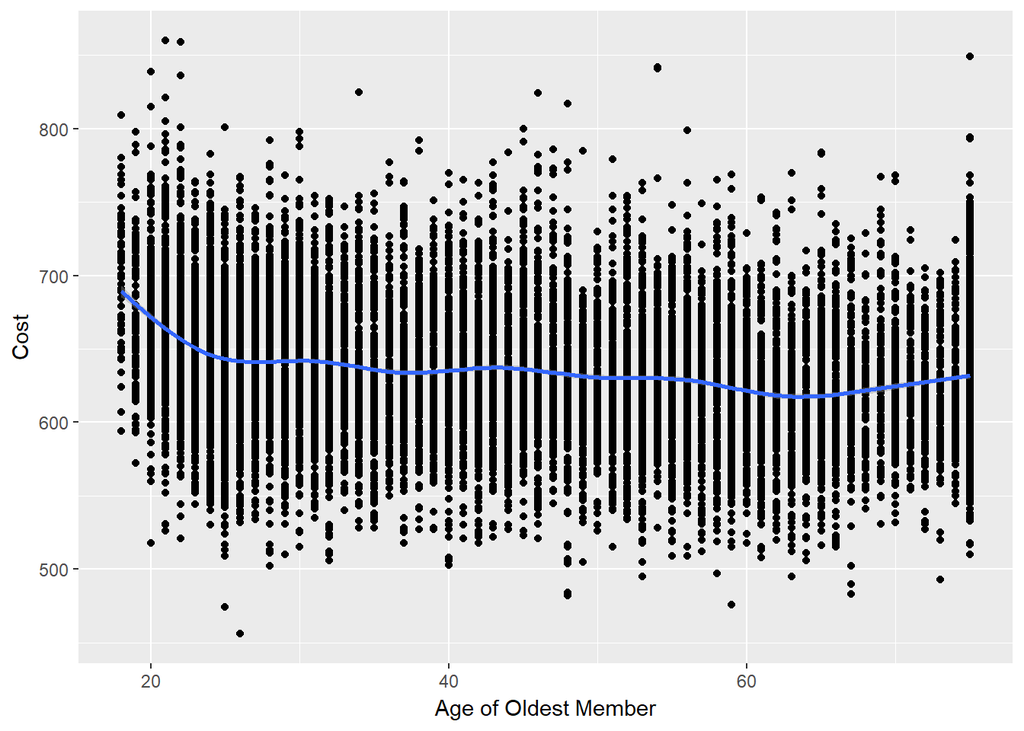

```r
qplot(allstate$age_oldest, allstate$cost, data = allstate) + geom_smooth() + xlab("Age of Oldest Member") + ylab("Cost")
```

### Age Youngest vs. Cost

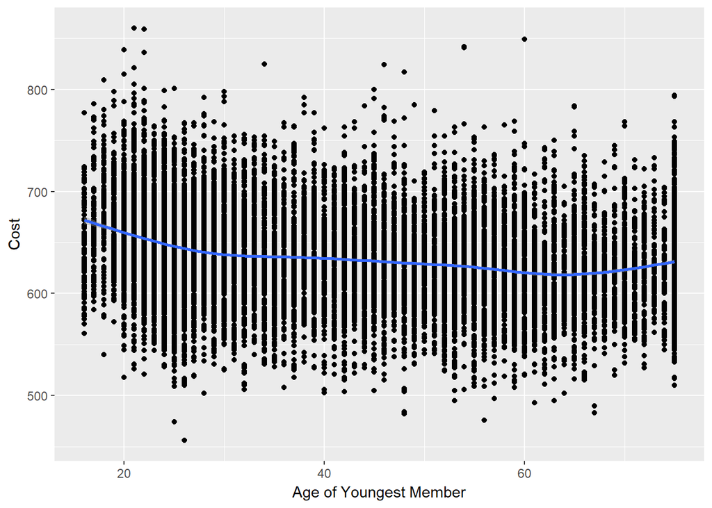

```r
qplot(allstate$age_youngest, allstate$cost, data = allstate) + geom_smooth() + xlab("Age of Youngest Member") + ylab("Cost")
```

### Married Couple vs. Cost

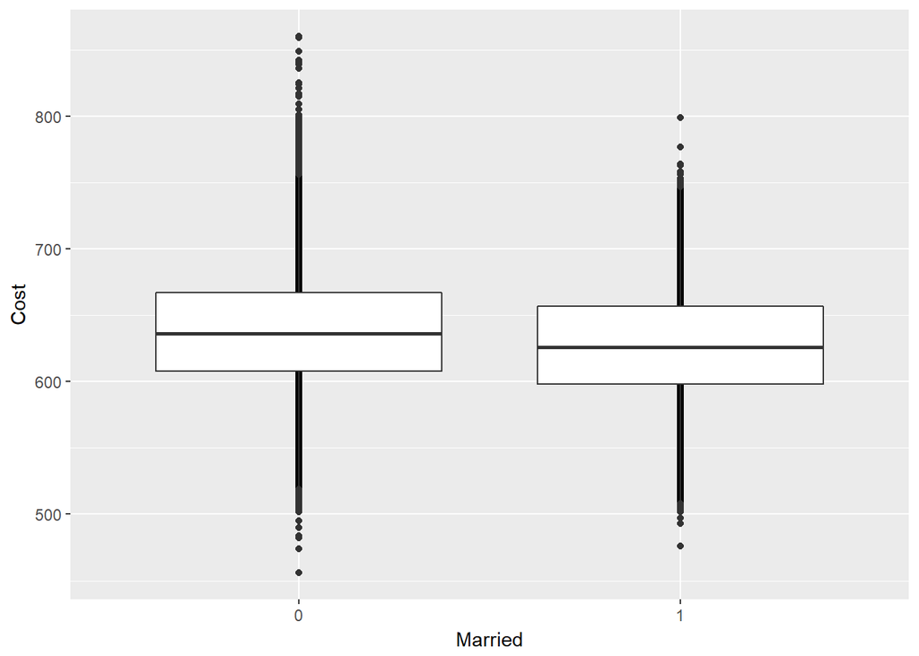

```r
qplot(factor(allstate$married_couple), allstate$cost, data = allstate) + geom_boxplot() + xlab("Married") + ylab("Cost")
```

### C previous vs. Cost

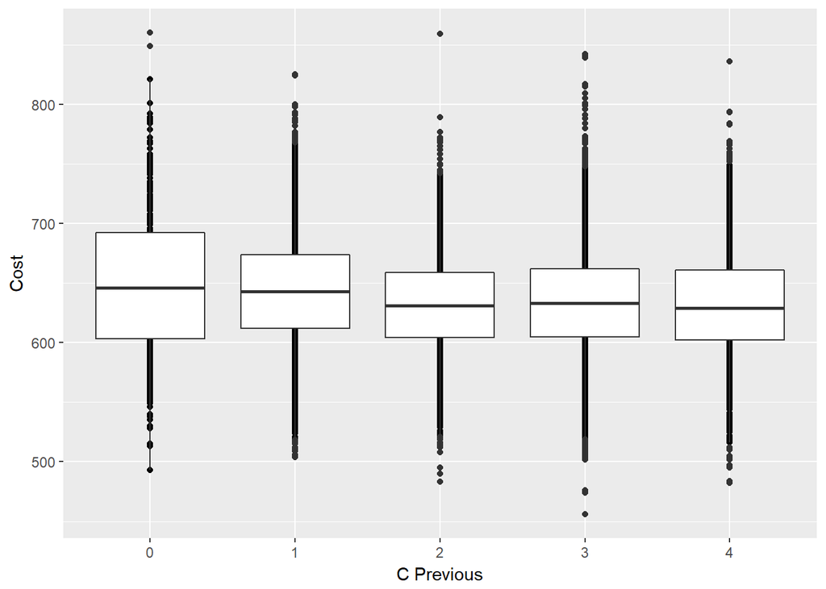

```r
qplot(factor(allstate$C_previous), allstate$cost, data = allstate) + geom_boxplot() + xlab("C Previous") + ylab("Cost")
```

### Duration Previous vs. Cost

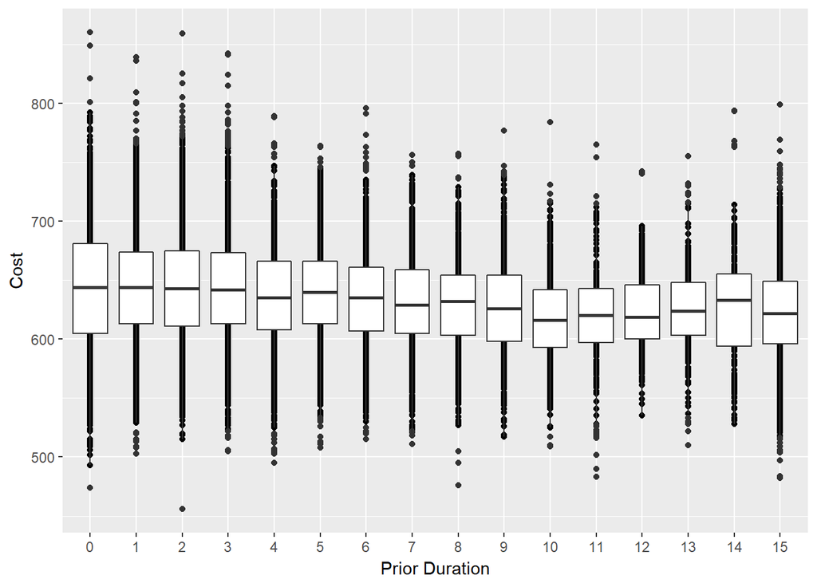

```r
qplot(factor(allstate$duration_previous), allstate$cost, data = allstate) + geom_boxplot() + xlab("Prior Duration") + ylab("Cost")
```

## Group Summarize

I used the group summarize function to come up with the mean for each customer for every variable and then added the mean cost to my working data set.

```r
group <- group_summarize(train_valid, customer_ID)
group <- select(group, customer_ID, cost_mean)
group
```

```
## # A tibble: 3,989 x 2
##    customer_ID cost_mean
##          <int>     <dbl>
##  1    10000000  633.4444
##  2    10000005  742.8333
##  3    10000007  608.3750
##  4    10000013  625.5000
##  5    10000014  602.0000
##  6    10000016  590.0000
##  7    10000019  685.5000
##  8    10000023  622.8571
##  9    10000025  605.2857
## 10    10000026  565.5000
## # ... with 3,979 more rows
```

I added the mean for each customer by left joining the two sets. This put a the mean cost value in every row per customer.

```r
allstate <- left_join(allstate, group, by = "customer_ID")
```

## Nearest Neighbors to Predict Plan

I used nearest neighbors to predict what plan the customers I am testing on would buy since I do not know that. Certain plans will most likely cost more than others so it is important to have the plan for predicting cost.

```r
library(FNN)


X <- as.matrix(select(allstate, customer_ID))
y <- allstate$id
X_train <- X[allstate$train_id == "Train" | allstate$train_id =="Valid",]
y_train <- y[allstate$train_id == "Train" | allstate$train_id =="Valid"]

allstate$id_pred <- knn(train = X_train, test = X,
                     cl = y_train, k = 3)
```

It gives me around a 67% to 70% accuracy for the train and valid sets and judging by looking at the values from the train set that have a record type of 1 it should predict around the same for my test set.

```r
tapply(allstate$id_pred == allstate$id, allstate$train_id, mean)
```

```
##      Test     Train     Valid
##        NA 0.6715274 0.6962425
```

Next I made a new variable called id1 that takes all the plans from the ones I know, so the train and valid set, but then uses the predictions from above for the test set.

```r
allstate$dummy <- 0
allstate$dummy[allstate$train_id == "Test"] <- 1

allstate$id[allstate$train_id == "Test"] <- 0

allstate$id1 <- as.numeric(as.character(allstate$id_pred)) * allstate$dummy + allstate$id

allstate$id[allstate$train_id == "Test"]=NA
```

## Dummy Variables for States

I made dummy variables for all the states that looked significant from the graph of the states shown earlier.

```r
allstate$IA <- 0
allstate$IA[allstate$state == "IA"] <- 1

allstate$DE <- 0
allstate$DE[allstate$state == "DE"] <- 1

allstate$Indiana <- 0
allstate$Indiana[allstate$state == "ID"] <- 1

allstate$RI <- 0
allstate$RI[allstate$state == "RI"] <- 1

allstate$DC <- 0
allstate$DC[allstate$state == "DC"] <- 1

allstate$SD <- 0
allstate$SD[allstate$state == "SD"] <- 1
```

## Glmnet

```r
library(glmnet)
X <- as.matrix(allstate[,c("customer_ID", "shopping_pt", "record_type", "day", "time", "location", "group_size", "homeowner", "car_age", "risk_factor", "age_oldest", "age_youngest", "married_couple", "C_previous", "duration_previous", "DE", "IA", "Indiana", "RI", "DC", "SD")])
y <- allstate$cost

X_train <- X[allstate$train_id == "Train",]
y_train <- y[allstate$train_id == "Train"]
X_valid <- X[allstate$train_id == "Test",]
y_valid <- y[allstate$train_id == "Test"]

model <- cv.glmnet(X_train, y_train, alpha = .9)

coef(model)
```

```
## 22 x 1 sparse Matrix of class "dgCMatrix"
##                               1
## (Intercept)       -1.156983e+03
## customer_ID        1.841136e-04
## shopping_pt        2.345514e-01
## record_type        .
## day                .
## time               .
## location           .
## group_size         1.283915e+00
## homeowner         -1.333184e+01
## car_age           -2.171591e+00
## risk_factor        2.715281e-01
## age_oldest         .
## age_youngest      -3.062344e-01
## married_couple    -4.208673e+00
## C_previous        -2.663736e+00
## duration_previous -1.077839e+00
## DE                 1.842041e+01
## IA                -2.318011e+01
## Indiana           -3.544444e+01
## RI                 2.454904e+01
## DC                 8.724686e+00
## SD                 .
```

## GAM Model

I put all the variable that were shown to be significant into the gam model as well as the mean cost and plan id with the predicted values from the knn model. It had a fairly good RMSE for both train and valid and did not appear to be too overfit.

```r
library(gam)
model <- gam(cost ~ homeowner + DE + IA + Indiana + RI + DC + s(car_age) + s(age_youngest) + married_couple + s(C_previous) + s(duration_previous) + s(id1) + s(cost_mean), subset = train_id == "Train",data = allstate)

allstate$gam_pred <- predict(model, newdata = allstate)


sqrt(tapply((allstate$cost - allstate$gam_pred)^2,
            allstate$train_id, mean))
```

```
##     Test    Train    Valid
##       NA 15.82522 15.11317
```

I checked to see how accurate is was on the Test set by comparing it with the Test Answers data set I had made earlier. The RMSE was around less than $18

```r
Test_Preds <- filter(allstate, allstate$train_id == "Test")
Test_Preds <- select(Test_Preds, customer_ID, gam_pred)
Test_Answers <- left_join(Test_Answers, Test_Preds, by = "customer_ID")
sqrt(tapply((Test_Answers$cost - Test_Answers$gam_pred)^2,
            Test_Answers$train_id, mean))
```

```
##     Test
## 17.61618
```

## Gradient Boosted Tree Model

```r
library(xgboost)
X <- model.matrix(~ .-1, data=allstate[,c("customer_ID", "shopping_pt", "record_type", "location", "group_size", "homeowner", "car_age", "risk_factor", "age_oldest", "age_youngest", "married_couple", "C_previous", "duration_previous", "cost_mean", "id1", "DE", "IA", "Indiana", "RI", "DC")])
y <- allstate$cost
X_train <- X[allstate$train_id == "Train",]
y_train <- y[allstate$train_id == "Train"]
X_valid <- X[allstate$train_id == "Valid",]
y_valid <- y[allstate$train_id == "Valid"]

data_train <- xgb.DMatrix(data = X_train, label = y_train)
data_valid <- xgb.DMatrix(data = X_valid, label = y_valid)
watchlist <- list(train=data_train, valid=data_valid)

model <- xgb.train(data = data_train,
                 max_depth = 4, eta = 0.01, nthread = 4,
                 nrounds = 5000, objective = "reg:linear",
                 watchlist = watchlist,
                 print_every_n = 1000)
allstate$xgb_pred <- predict(model, newdata = X)
sqrt(tapply((allstate$cost - allstate$xgb_pred)^2,
            allstate$train_id, mean))
```

```
##     Test    Train    Valid
##       NA 11.89345 15.65326
```

On the Test set however, it was about $1 worse than the gam model.

```r
Test_Preds <- filter(allstate, allstate$train_id == "Test")
Test_Preds <- select(Test_Preds, customer_ID, xgb_pred)
Test_Answers <- left_join(Test_Answers, Test_Preds, by = "customer_ID")
sqrt(tapply((Test_Answers$cost - Test_Answers$xgb_pred)^2,
            Test_Answers$train_id, mean))
```

```
##     Test
## 18.75646
```

## Nearest Neighbors Model

The last model I tried was a k nearest neighbors model. I used a k of 3 and only customer ID as the matching variable because I wanted to compare it to the previous quotes that the customer asked for previously.

```r
X <- as.matrix(select(allstate, customer_ID))
y <- allstate$cost
X_train <- X[allstate$train_id == "Train" | allstate$train_id =="Valid",]
y_train <- y[allstate$train_id == "Train" | allstate$train_id =="Valid"]

allstate$knn_pred <- knn(train = X_train, test = X,
                     cl = y_train, k = 3)

allstate$knn_pred <- as.numeric(as.character(allstate$knn_pred))

sqrt(tapply((allstate$cost - allstate$knn_pred)^2,
            allstate$train_id, mean))
```

```
##     Test    Train    Valid
##       NA 22.13998 20.89674
```

This gave me the best RMSE out of any of the models with it being about $17.31

```r
Test_Preds <- filter(allstate, allstate$train_id == "Test")
Test_Preds <- select(Test_Preds, customer_ID, knn_pred)
Test_Answers <- left_join(Test_Answers, Test_Preds, by = "customer_ID")
sqrt(tapply((Test_Answers$cost - Test_Answers$knn_pred)^2,
            Test_Answers$train_id, mean))
```

```
##     Test
## 17.30819
```

## Blended Model

Finally I blended the model. This decreased RMSE only slightly from before.

```r
model <- lm(cost ~ xgb_pred + gam_pred + knn_pred,
            data = allstate,
            subset = (train_id == "Valid"))
summary(model)
```

```
##
## Call:
## lm(formula = cost ~ xgb_pred + gam_pred + knn_pred, data = allstate,
##     subset = (train_id == "Valid"))
##
## Residuals:
##      Min       1Q   Median       3Q      Max
## -112.018   -6.789   -1.073    5.796  146.448
##
## Coefficients:
##             Estimate Std. Error t value Pr(>|t|)
## (Intercept) 13.30403    2.75218   4.834 1.37e-06 ***
## xgb_pred     0.43944    0.02080  21.132  < 2e-16 ***
## gam_pred     0.48587    0.02735  17.768  < 2e-16 ***
## knn_pred     0.05362    0.01312   4.087 4.42e-05 ***
## ---
## Signif. codes:  0 '***' 0.001 '**' 0.01 '*' 0.05 '.' 0.1 ' ' 1
##
## Residual standard error: 14.61 on 6330 degrees of freedom
## Multiple R-squared:  0.8983, Adjusted R-squared:  0.8982
## F-statistic: 1.863e+04 on 3 and 6330 DF,  p-value: < 2.2e-16
```

This gave me very good Train and Valid RMSE values

```r
allstate$blend_pred <- predict(model, newdata = allstate)

sqrt(tapply((allstate$cost - allstate$blend_pred)^2,
            allstate$train_id, mean))
```

```
##     Test    Train    Valid
##       NA 13.80085 14.60483
```

The blended model turned out to be the best model, slightly better than the knn model but it incorporates other factors as well.

```r
Test_Preds <- filter(allstate, allstate$train_id == "Test")
Test_Preds <- select(Test_Preds, customer_ID, blend_pred)
Test_Answers <- left_join(Test_Answers, Test_Preds, by = "customer_ID")
sqrt(tapply((Test_Answers$cost - Test_Answers$blend_pred)^2,
            Test_Answers$train_id, mean))
```

```
##     Test
## 17.30256
```

## Conclusion

I would either choose the blended model or the gam model if I were predicting new customers. While the knn model has the lowest individual RMSE it is solely basing it off of previously looked at quotes from the customer so if the customer changed more drastically for their final purchase then it would not be able to predict accurately. Whereas the GAM model takes into account more factors so it can better adapt to odd values if a customer is doing more abnormal shopping.